# Questionnaire exploration

A new article created using the Distill format.

Carlos Cámara-Menoyo https://carloscamara.es/ (University of Warwick)https://warwick.ac.uk , Tessio Novack (University of Warwick)https://warwick.ac.uk , James Tripp (University of Warwick)https://warwick.ac.uk  
2022-04-20

# Introduction

We are analysing **1440 responses** from a questionnaire published between 2022-02-17 11:06:27 and 2022-04-13 20:13:47.

Respondents were selected following these groups: Prolific 1, Prolific 2

# Research questions

- Does demographics influence in the perceived walkability?
  - Are some demographics more decisive than others?
- Does location influence the ratings?
- Does our clusters’ classification influence perceived walkability?
  - Do they work?

# Results

## Overall

In this section we are showing results without aggregation.

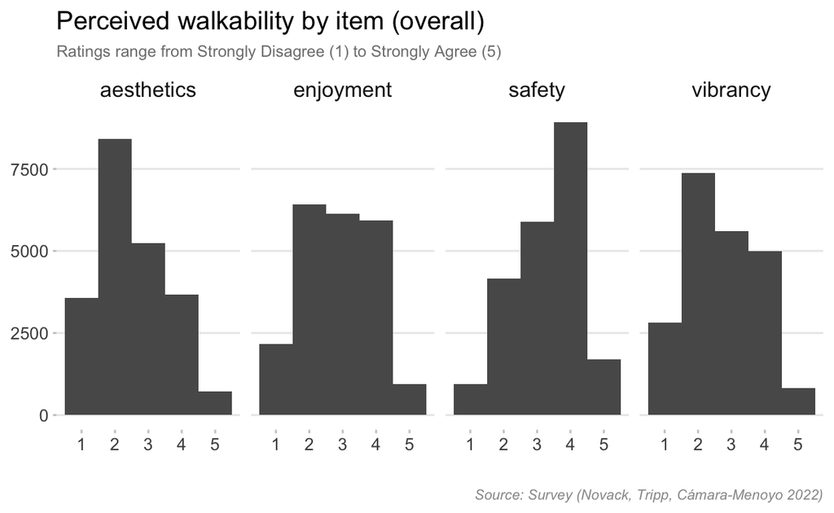

Figure 1: Histogram of ratings (no aggregation)

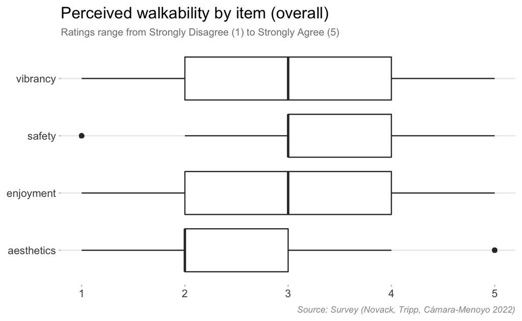

Figure 2: Overall distribution of ratings by walkability item

Figure 2 shows that vibrancy, safety and enjoyment have the same mean (Neutral), whereas aesthetics’ mean is lower (Disagree). Furthermore, vibrancy and enjoyment seem to have a similar distribution in ratings, suggesting that, either people do no differentiate between these two concepts or they were ill-defined.

## Perceptions by demographics

In this section we will be aggregating ratings by gender, age, ethnicity, sexual orientation, immigration background, disabilities affecting mobility, and local knowledge. By doing so, we expect to identify some demographics that are more relevant than others

TODO: combine more than one demographic?

### By Gender

Table 1: Number of respondents per genre

| gender | n |
| --- | --- |
| Female | 720 |
| Male | 676 |
| Non-binary | 38 |
| Other | 6 |

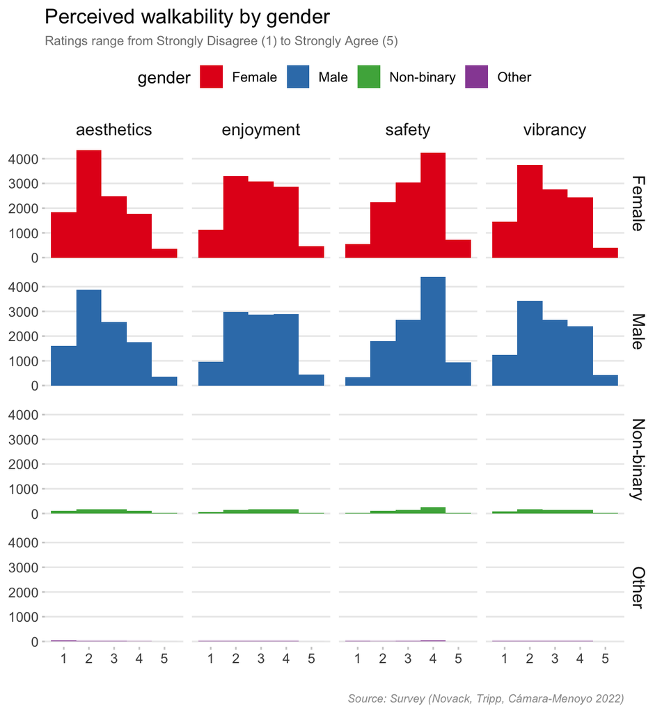

Figure 3: Ratings by genre (histogram)

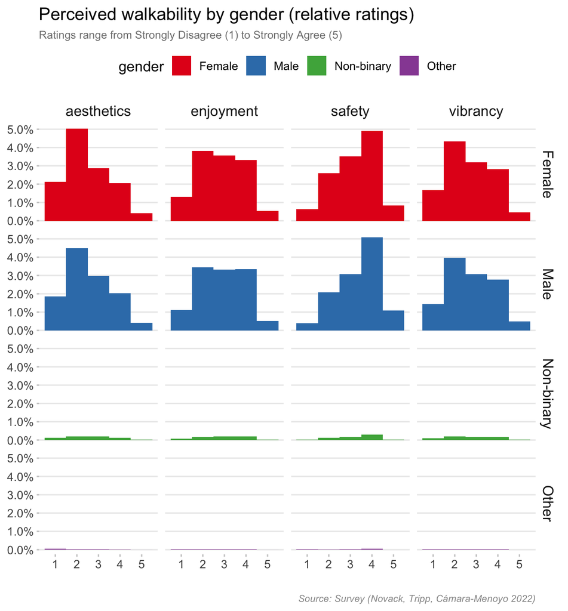

Figure 4: Ratings by genre (histogram)

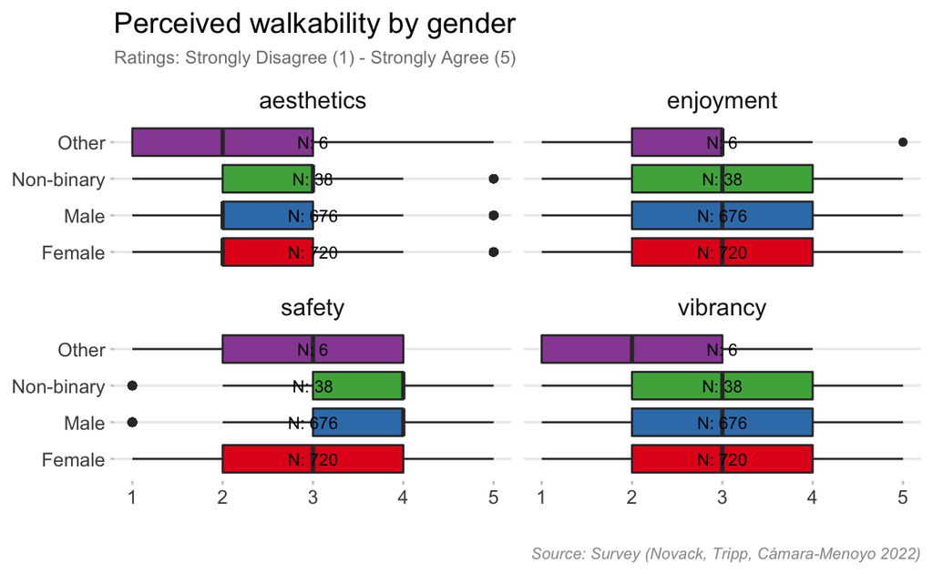

Figure 5: Ratings by genre (boxplot)

### By Age

The table below shows age distribution

Table 2: Number of respondents per age

| age | n |
| --- | --- |
| 18 - 24 | 318 |
| 25 - 34 | 455 |
| 35 - 44 | 291 |
| 45 - 54 | 182 |
| 55 - 64 | 134 |
| 65 - 74 | 55 |
| 75 or older | 5 |

[figure not shown]

Figure 6: Ratings by age (histogram)

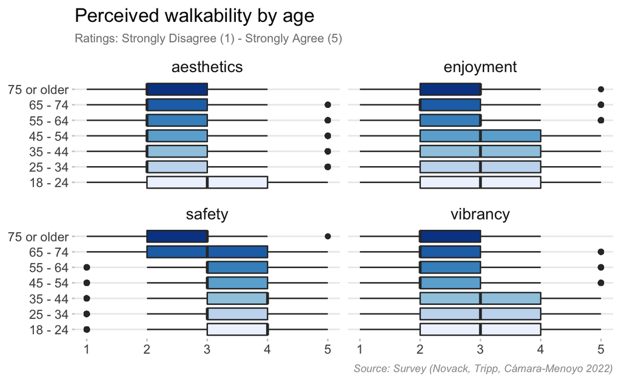

Figure 7: Ratings by age

The older we get, the less aesthetically appealing we find streets. No significant differences in enjoyment. Safety: only young adults seem to feel safer (probably they feel safer and more confindent in every aspect of their lifes?), then those between 35-44. At 65, ratings are more skewed towards lower values.

### By ethnicity

The table below shows ethnicity distribution

Table 3: Number of respondents per ethnicity

| ethnicity | n |
| --- | --- |
| Asian or Asian British | 93 |
| Black, African, Caribbean or Black British | 33 |
| Mixed or Multiple ethnic groups | 51 |
| Other ethnic group | 20 |
| White | 1243 |

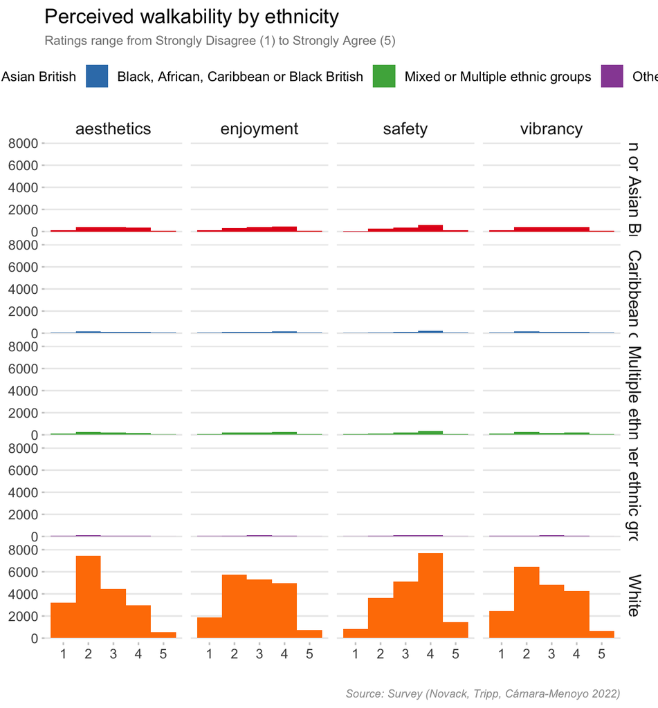

Figure 8: Ratings by ethnicity (histogram)

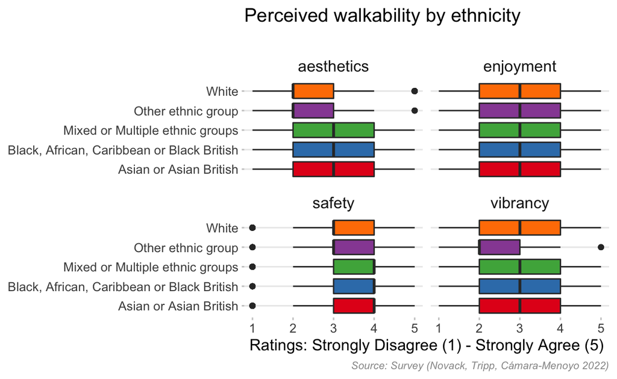

Figure 9: Ratings by ethnicity

### By sexual orientation

Table 4: Number of respondents per sexual orientation

| sexual_orientation_selected_choice | n |
| --- | --- |
| Asexual | 54 |
| Bisexual | 344 |
| Gay | 149 |
| Heterosexual | 766 |
| Lesbian | 65 |
| None of the above, please specify | 6 |
| Pansexual | 34 |
| Queer | 22 |

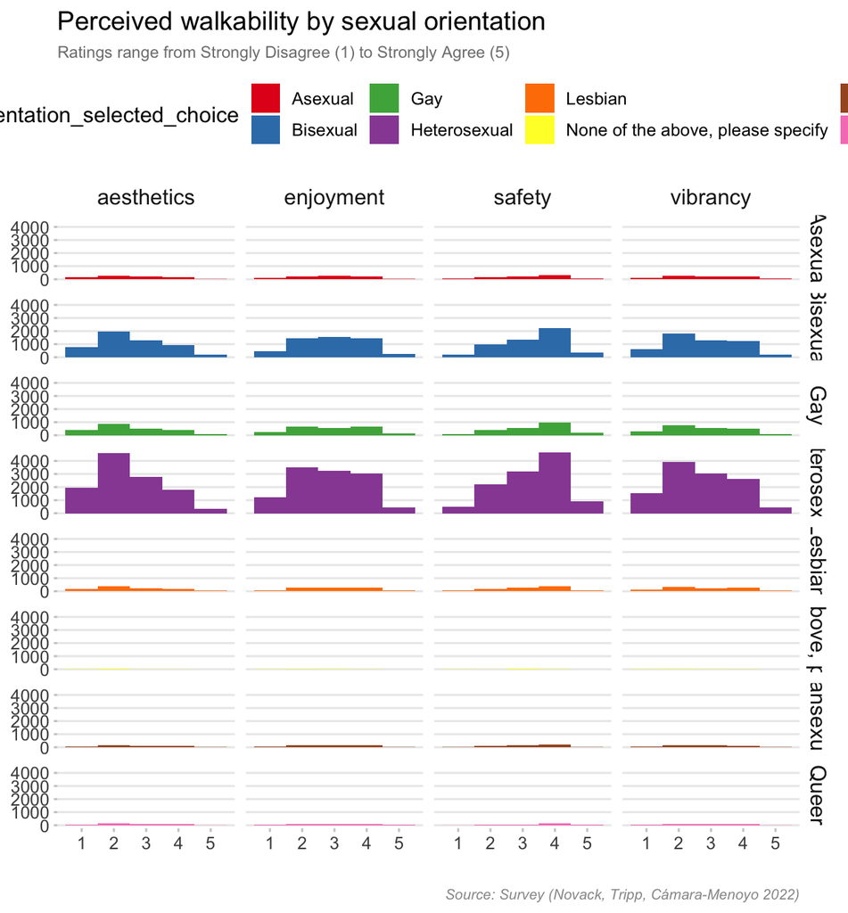

Figure 10: Ratings by sexual orientation (histogram)

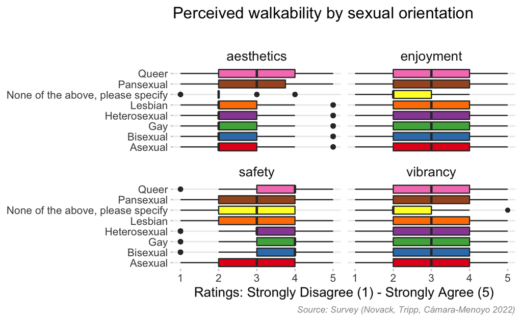

Figure 11: Ratings by Sexual orientation

I believe we should combine some categories: gay + queer for sure, and probably gay + queer + lesbian into homosexual?

### By immigration status

Table 5: Number of respondents per immigration background

| immigration_background | n |
| --- | --- |
| No | 1179 |
| Yes | 261 |

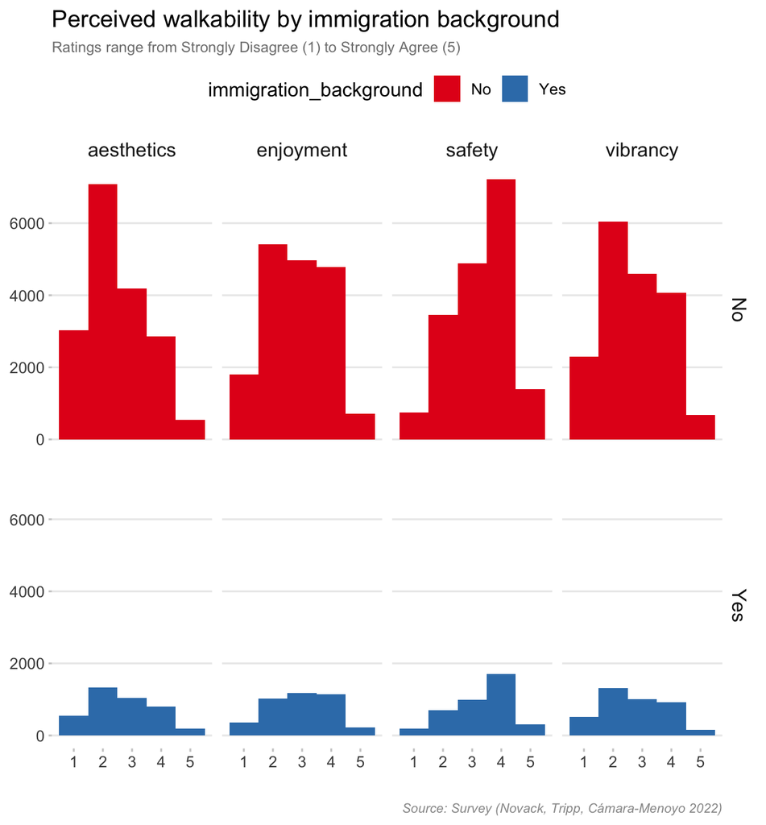

Figure 12: Ratings by immigration background (histogram)

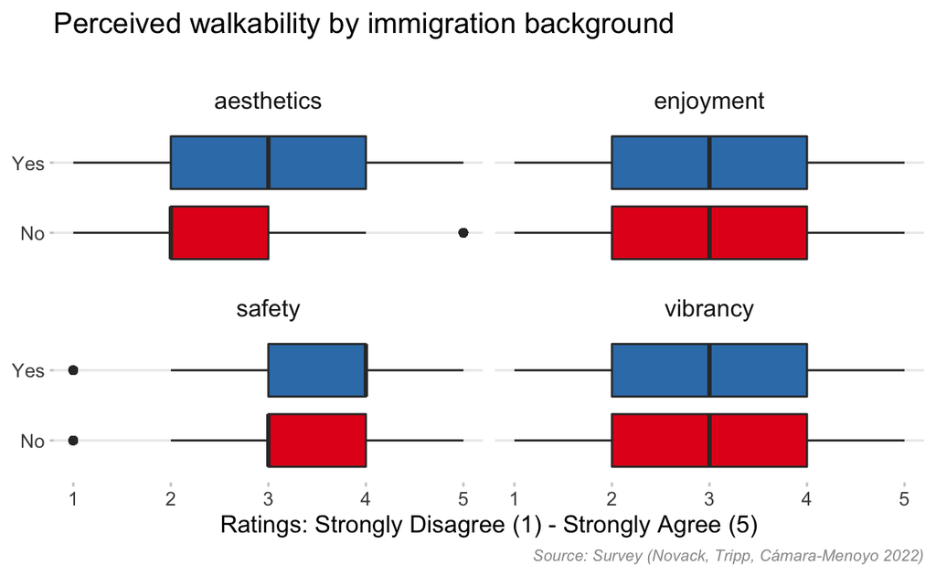

Figure 13: Ratings by immigration background

TODO: rename “yes” -> Immigration background, no -> “?”

I didn’t expected to see that people with immigration backgrounds perceive streets to be safer.

### By disabilities

| mobility_disabilities | n |
| --- | --- |
| No | 1301 |
| Yes | 139 |

[figure not shown]

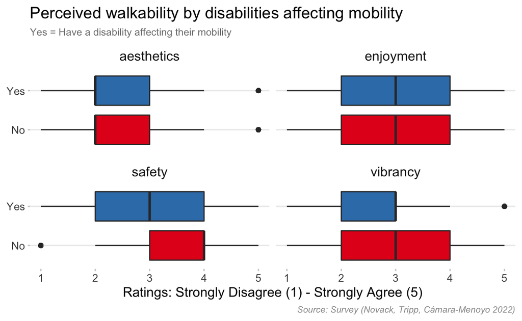

Figure 15: Ratings by disabilities affecting mobility

### By local knowledge

TODO: sort answers by correct order (0-4) in the data preparations’ file.

| local_knowledge_london | n |
| --- | --- |
| I do not know London at all(0) | 152 |
| I know London as the back of my hand(4) | 44 |
| I know London poorly(1) | 414 |
| I know London to an extent(2) | 576 |
| I know London very well(3) | 254 |

[figure not shown]

Figure 16: Ratings by local knowledge (histogram)

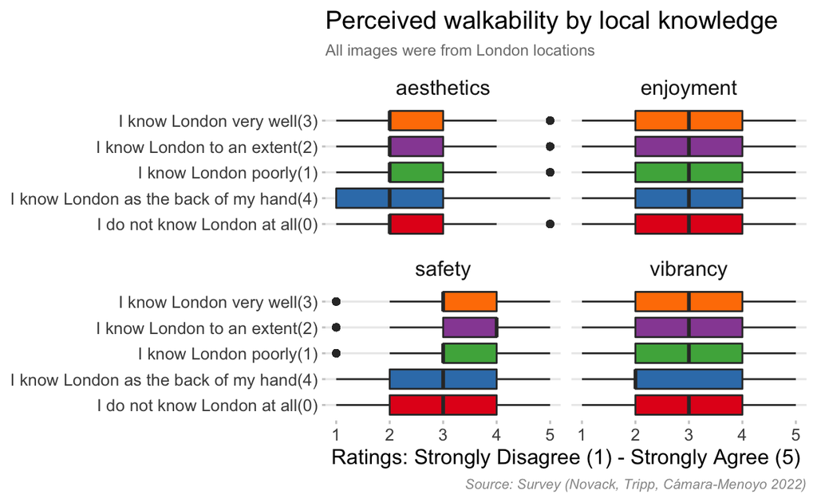

Figure 17: Ratings by London’s local knowledge

## Perceptions by cluster

Locations were grouped in five clusters, based exclusively in the features present in the four images of the same location, using a ML algorithm (see [repo here](https://github.com/WarwickCIM/walkability_ml)). Location was not considered.

In this case N is the number of ratings received, and all of them received the same ratings, by design.r

Table 8: Number of respondents per cluster

| cluster | n |
| --- | --- |
| C0 | 17280 |
| C1 | 17280 |
| C2 | 17280 |
| C3 | 17280 |
| C4 | 17280 |

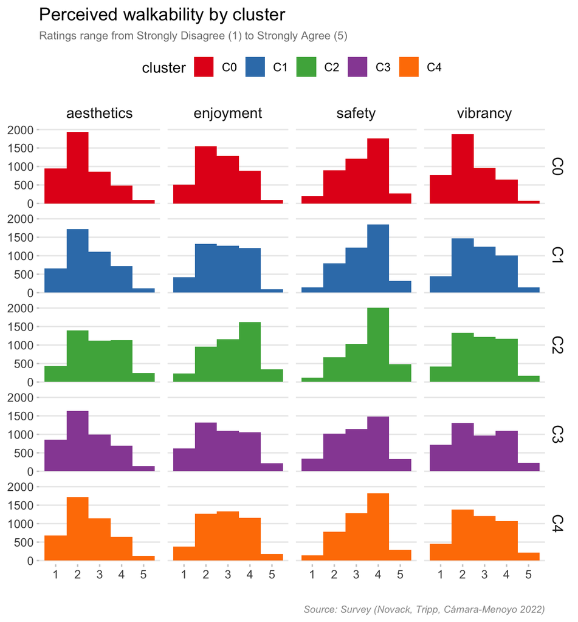

Figure 18: Ratings by cluster (histogram)

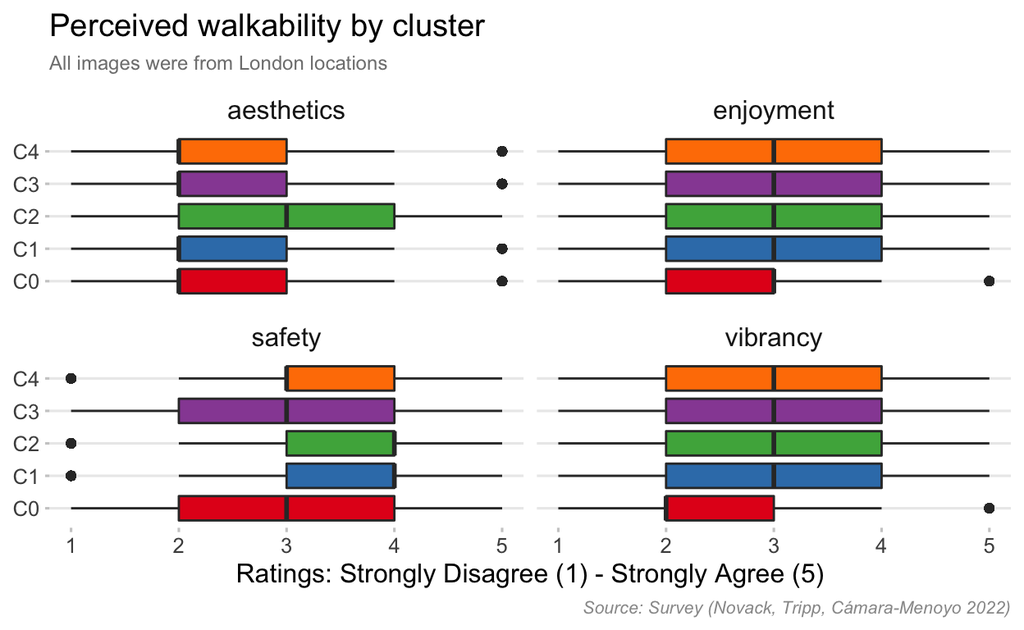

Figure 19: Ratings by Image cluster

## Perceptions by geographic area

[interactive chart not shown]

(Reference https://cengel.github.io/R-data-viz/domains.html#maps-e.g.-tmap)

Tessio, since you have the location of every location, we could create a map and see:

- if ratings respond to geographic locations (are there some areas which are less walkable than others?)
- if there’s correlation between ratings and osm tagging (i.e. `highway = primary` is always more walkable than `highway = alley` obviously, this is a stupid example, but we could use highway=*, smoothness=*, width=* , or even do some spatial calculations such as distance to certain amenities, trees, parks…)

# Conclusions

I’m afraid we have bad news:

- Usually, there are no differences between groups
- Usually, the mean for every item is 3 (neutral) -> not very useful -> we might have used numeric values?
  - We might want to re-scale the answers to a scale from 1-4?
- This is true in general for every item and every social group, with few exceptions:
  - Safety
  - aesthetics (to a much lesser extent) -> to be explored if it differs from people within the UK and outside
- Differences are usually spotted into groups with less participants.
- But, what is more to me: the results seem to be random: if we generated a random set of answers we might get a similar result. I’m starting to question if people (especially fast responders from prolific) have answered randomly to get paid -> repeat results and filter those which have taken less than 10 minutes?
  - Introduce some validation in qualtrics? -> i.e. timing or if answers are too similar to the random ones.
- This might be a problem of visualisation used or the fact that the number of people -> could you think of better ones?